# STAT3926/STAT4026: Statistical Consulting

Survival Analysis

Authors

Prepared by: 510288769

Prepared for: David Foxe

Published

May 17, 2024

## Background

Previously, the client implemented a Kaplan-Meier survival curve to model the survival predictions across different types of dementia.

## Client’s Aims

The client has two aims for this project. The first is to produce an interactive graph that provides a comprehensive exploration of the time from formal diagnosis to death based on four key covariates: age at diagnosis, sex, disease duration at diagnosis, and overall cognitive performance measured by the ACE-III test. These covariates were selected by the client based on their expertise and the availability of data. The second aim is to explore additional variables, including those from the Cambridge Behavioural Inventory-Revised carer questionnaire, family history of dementia as defined by a Goldman Score, and cognitive abilities. The client suspects these variables may influence survival rates and wants more clarity on the extent of the impact each factor has on survival.

## Model

To meet the client’s objective of understanding how various covariates affect different dementia patient groups, we implemented a Cox Proportional Hazards regression model for each type of dementia, serving as the foundation of the interactive survival graph. This approach was informed by previous client analyses that highlighted statistically significant survival differences across dementia diagnoses. Each model accounted for age at diagnosis, sex, disease duration at diagnosis, and overall cognitive performance as assessed by the ACE-III test. While the Cox regression model does not assume any underlying data distribution, it does require other assumptions to be satisfied (details in the appendix).

## Interactive Survival Graph

Patient Group 1

Age at Diagnosis

Disease duration at diagnosis

ACEIII Total

Sex

Male Female

Diagnosis

AD lvPPA bvFTD svPPA nfvPPA nfvPPA + Parkinson’s plus CBS PSP FTD-MND

Patient Group 2

Age at Diagnosis

Disease duration at diagnosis

ACEIII Total

Sex

Male Female

Diagnosis

AD lvPPA bvFTD svPPA nfvPPA nfvPPA + Parkinson’s plus CBS PSP FTD-MND

## Significance of variables

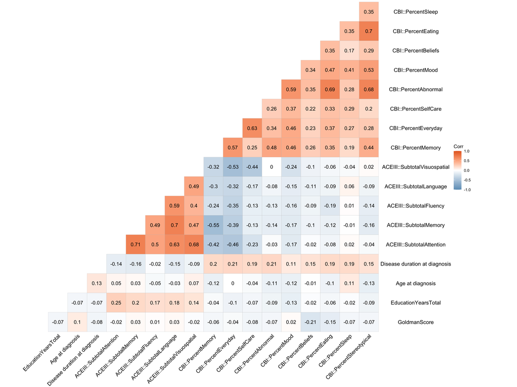

### Overall significance for all dementia diagnosis

|  | Coefficient | Std. Error | z value | p value |
| --- | --- | --- | --- | --- |
| (Intercept) | 1.6287042 | 0.0991719 | 16.4230431 | 0.0000000 |
| Diagnosis_nameFTD-MND | -1.3149343 | 0.1465575 | -8.9721390 | 0.0000000 |
| Log(scale) | -0.6053870 | 0.0421825 | -14.3516303 | 0.0000000 |
| Diagnosis_namenfvPPA + Parkinson’s plus | -0.2807378 | 0.1883152 | -1.4907868 | 0.1360175 |
| Diagnosis_namelvPPA | -0.2083461 | 0.1400319 | -1.4878470 | 0.1367912 |
| Diagnosis_namenfvPPA | -0.1942113 | 0.1576234 | -1.2321225 | 0.2179033 |
| ACEIII::SubtotalFluency | 0.1758444 | 0.0477791 | 3.6803610 | 0.0002329 |
| ACEIII::SubtotalVisuospatial | 0.1300042 | 0.0559673 | 2.3228600 | 0.0201867 |
| CBI::PercentSelfCareFCorrected | -0.1291601 | 0.0496838 | -2.5996408 | 0.0093321 |
| Sex (Male 1, Female 2) 2 | 0.1117217 | 0.0726728 | 1.5373244 | 0.1242139 |
| CBI::PercentMemoryFCorrected | 0.1082240 | 0.0557348 | 1.9417675 | 0.0521652 |
| ACEIII::SubtotalMemory | -0.0980801 | 0.0644657 | -1.5214318 | 0.1281515 |
| Diagnosis_namebvFTD | -0.0789263 | 0.1392427 | -0.5668258 | 0.5708326 |
| Disease duration at diagnosis | 0.0776235 | 0.0361458 | 2.1475100 | 0.0317527 |
| CBI::PercentMotivationFCorrected | -0.0761239 | 0.0533105 | -1.4279338 | 0.1533109 |
| Age at diagnosis | -0.0621485 | 0.0376262 | -1.6517348 | 0.0985886 |
| CBI::PercentAbnormalFCorrected | -0.0554625 | 0.0575207 | -0.9642179 | 0.3349367 |
| Diagnosis_namesvPPA | 0.0506025 | 0.1866061 | 0.2711727 | 0.7862582 |
| Diagnosis_namePSP | -0.0503900 | 0.1746879 | -0.2884574 | 0.7729967 |
| ACEIII::SubtotalAttention | 0.0499284 | 0.0620538 | 0.8045995 | 0.4210508 |
| ClinicalAssessment::GoldmanScore | 0.0471112 | 0.0355100 | 1.3267019 | 0.1846073 |
| CBI::PercentSleepFCorrected | -0.0468760 | 0.0396049 | -1.1835893 | 0.2365757 |
| Diagnosis_nameCBS | -0.0467270 | 0.1698713 | -0.2750732 | 0.7832600 |
| CBI::PercentEverydayFCorrected | -0.0387882 | 0.0580971 | -0.6676443 | 0.5043607 |
| CBI::PercentMoodFCorrected | 0.0335674 | 0.0504296 | 0.6656296 | 0.5056479 |
| CBI::PercentBeliefsFCorrected | 0.0168583 | 0.0374950 | 0.4496140 | 0.6529888 |
| EducationYearsTotal | 0.0100432 | 0.0371356 | 0.2704470 | 0.7868164 |
| CBI::PercentStereotypicalFCorrected | 0.0074927 | 0.0546087 | 0.1372075 | 0.8908668 |
| ACEIII::SubtotalLanguage | -0.0072250 | 0.0622213 | -0.1161174 | 0.9075595 |
| CBI::PercentEatingFCorrected | -0.0030126 | 0.0564909 | -0.0533295 | 0.9574693 |

```
                       AD                     bvFTD                       CBS
                       49                        61                        25
                  FTD-MND                     lvPPA                    nfvPPA
                       35                        27                        29
nfvPPA + Parkinson’s plus                       PSP                     svPPA
                       13                        21                        21
```

```
                                Coefficient Std. Error    z value      p value
(Intercept)                      1.62870420 0.09917189  16.423043 1.308371e-60
Diagnosis_nameFTD-MND           -1.31493430 0.14655751  -8.972139 2.908112e-19
Disease duration at diagnosis    0.07762345 0.03614579   2.147510 3.175270e-02
ACEIII::SubtotalFluency          0.17584443 0.04777912   3.680361 2.329040e-04
ACEIII::SubtotalVisuospatial     0.13000423 0.05596731   2.322860 2.018667e-02
CBI::PercentSelfCareFCorrected  -0.12916013 0.04968384  -2.599641 9.332139e-03
Log(scale)                      -0.60538699 0.04218245 -14.351630 1.040619e-46
```

```
                                Coefficient Std. Error    z value      p value
(Intercept)                      1.62870420 0.09917189  16.423043 1.308371e-60
Diagnosis_nameFTD-MND           -1.31493430 0.14655751  -8.972139 2.908112e-19
Disease duration at diagnosis    0.07762345 0.03614579   2.147510 3.175270e-02
ACEIII::SubtotalFluency          0.17584443 0.04777912   3.680361 2.329040e-04
ACEIII::SubtotalVisuospatial     0.13000423 0.05596731   2.322860 2.018667e-02
CBI::PercentSelfCareFCorrected  -0.12916013 0.04968384  -2.599641 9.332139e-03
Log(scale)                      -0.60538699 0.04218245 -14.351630 1.040619e-46
```

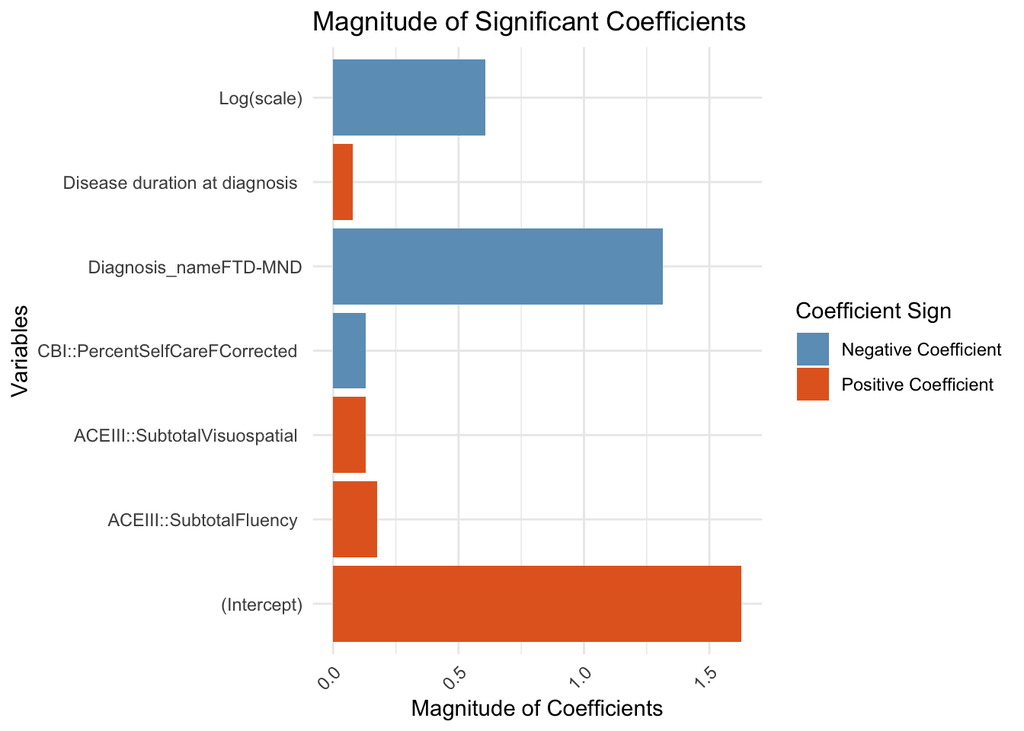

## Appendix

### Testing Proportional Harzard

**AD**

| Covariate | Chisq | Degrees of Freedom | p-value |
| --- | --- | --- | --- |
| Age at diagnosis | 1.24 | 1 | 0.266 |
| Sex | 1.35 | 1 | 0.246 |
| Disease duration at diagnosis | 0.17 | 1 | 0.682 |
| ACE-III Total | 1.09 | 1 | 0.297 |
| GLOBAL | 3.25 | 4 | 0.517 |

**bvFTD**

| Covariate | Chisq | Degrees of Freedom | p-value |
| --- | --- | --- | --- |
| Age at diagnosis | 0.42 | 1 | 0.517 |
| Sex | 6.61 | 1 | 0.010 |
| Disease duration at diagnosis | 0.41 | 1 | 0.523 |
| ACE-III Total | 1.02 | 1 | 0.312 |
| GLOBAL | 9.12 | 4 | 0.058 |

**CBS**

| Covariate | Chisq | Degrees of Freedom | p-value |
| --- | --- | --- | --- |
| Age at diagnosis | 0.05 | 1 | 0.826 |
| Sex | 1.88 | 1 | 0.170 |
| Disease duration at diagnosis | 0.01 | 1 | 0.933 |
| ACE-III Total | 1.64 | 1 | 0.200 |
| GLOBAL | 3.87 | 4 | 0.424 |

**nfvPPA + Parkinson’s plus**

| Covariate | Chisq | Degrees of Freedom | p-value |
| --- | --- | --- | --- |
| Age at diagnosis | 0.36 | 1 | 0.548 |
| Sex | 0.05 | 1 | 0.824 |
| Disease duration at diagnosis | 0.84 | 1 | 0.358 |
| ACE-III Total | 4.50 | 1 | 0.034 |
| GLOBAL | 6.95 | 4 | 0.139 |

**FTD-MND**

| Covariate | Chisq | Degrees of Freedom | p-value |
| --- | --- | --- | --- |
| Age at diagnosis | 0.00 | 1 | 0.992 |
| Sex | 0.12 | 1 | 0.731 |
| Disease duration at diagnosis | 2.92 | 1 | 0.088 |
| ACE-III Total | 0.01 | 1 | 0.905 |
| GLOBAL | 3.86 | 4 | 0.425 |

**lvPPA**

| Covariate | Chisq | Degrees of Freedom | p-value |
| --- | --- | --- | --- |
| Age at diagnosis | 0.08 | 1 | 0.782 |
| Sex | 1.50 | 1 | 0.220 |
| Disease duration at diagnosis | 4.85 | 1 | 0.028 |
| ACE-III Total | 1.57 | 1 | 0.211 |
| GLOBAL | 10.68 | 4 | 0.030 |

**nfvPPA**

| Covariate | Chisq | Degrees of Freedom | p-value |
| --- | --- | --- | --- |
| Age at diagnosis | 0.12 | 1 | 0.734 |
| Sex | 0.05 | 1 | 0.832 |
| Disease duration at diagnosis | 1.25 | 1 | 0.263 |
| ACE-III Total | 0.78 | 1 | 0.377 |
| GLOBAL | 2.34 | 4 | 0.674 |

**PSP**

| Covariate | Chisq | Degrees of Freedom | p-value |
| --- | --- | --- | --- |
| Age at diagnosis | 0.15 | 1 | 0.702 |
| Sex | 0.07 | 1 | 0.796 |
| Disease duration at diagnosis | 0.14 | 1 | 0.705 |
| ACE-III Total | 2.46 | 1 | 0.117 |
| GLOBAL | 2.87 | 4 | 0.579 |

**svPPA**

| Covariate | Chisq | Degrees of Freedom | p-value |
| --- | --- | --- | --- |
| Age at diagnosis | 0.12 | 1 | 0.734 |
| Sex | 0.00 | 1 | 0.972 |
| Disease duration at diagnosis | 0.39 | 1 | 0.530 |
| ACE-III Total | 0.76 | 1 | 0.384 |
| GLOBAL | 3.47 | 4 | 0.483 |

**AD**

|  | Coefficient | Std. Error | z value | p value |
| --- | --- | --- | --- | --- |
| (Intercept) | 1.9750823 | 0.1304882 | 15.1361021 | 0.0000000 |
| Log(scale) | -1.0695636 | 0.1010153 | -10.5881398 | 0.0000000 |
| ACEIII::SubtotalVisuospatial | 0.3234895 | 0.0731973 | 4.4194162 | 0.0000099 |
| CBI::PercentEating | 0.2350261 | 0.1710496 | 1.3740229 | 0.1694346 |
| Age at diagnosis | -0.2089849 | 0.0555404 | -3.7627564 | 0.0001681 |
| CBI::PercentSelfCare | -0.1704212 | 0.1295625 | -1.3153584 | 0.1883895 |
| EducationYearsTotal | -0.1431628 | 0.0674650 | -2.1220319 | 0.0338351 |
| Sex (Male 1, Female 2) 2 | 0.1286976 | 0.1178721 | 1.0918412 | 0.2749029 |
| ACEIII::SubtotalLanguage | -0.1268934 | 0.1546210 | -0.8206738 | 0.4118321 |
| Disease duration at diagnosis | -0.1220367 | 0.0729627 | -1.6725902 | 0.0944080 |
| ACEIII::SubtotalAttention | 0.1068610 | 0.1215558 | 0.8791107 | 0.3793413 |
| CBI::PercentAbnormal | -0.0803797 | 0.1685262 | -0.4769568 | 0.6333929 |
| ACEIII::SubtotalFluency | -0.0736457 | 0.0967825 | -0.7609406 | 0.4466925 |
| GoldmanScore | 0.0730915 | 0.1044951 | 0.6994732 | 0.4842564 |
| CBI::PercentMotivation | -0.0712989 | 0.1096646 | -0.6501540 | 0.5155927 |
| CBI::PercentSleep | -0.0653759 | 0.0751421 | -0.8700306 | 0.3842837 |
| CBI::PercentStereotypical | -0.0629505 | 0.1336806 | -0.4709021 | 0.6377107 |
| ACEIII::SubtotalMemory | 0.0517398 | 0.1237023 | 0.4182605 | 0.6757567 |
| CBI::PercentMemory | -0.0411183 | 0.1035539 | -0.3970718 | 0.6913145 |
| CBI::PercentMood | 0.0392490 | 0.0953593 | 0.4115904 | 0.6806397 |
| CBI::PercentBeliefs | -0.0282680 | 0.0972206 | -0.2907617 | 0.7712336 |
| CBI::PercentEveryday | 0.0050338 | 0.1057047 | 0.0476213 | 0.9620180 |

**bvFTD**

|  | Coefficient | Std. Error | z value | p value |
| --- | --- | --- | --- | --- |
| (Intercept) | 1.5303344 | 0.1170029 | 13.0794614 | 0.0000000 |
| Log(scale) | -0.8642163 | 0.0905357 | -9.5455812 | 0.0000000 |
| ACEIII::SubtotalVisuospatial | 0.3778851 | 0.1298433 | 2.9103170 | 0.0036106 |
| Sex (Male 1, Female 2) 2 | 0.2886560 | 0.1653018 | 1.7462366 | 0.0807698 |
| ACEIII::SubtotalFluency | 0.2565609 | 0.0770503 | 3.3297847 | 0.0008691 |
| CBI::PercentMemory | 0.2381783 | 0.0976174 | 2.4399175 | 0.0146906 |
| CBI::PercentMotivation | -0.1902755 | 0.1033317 | -1.8414041 | 0.0655624 |
| CBI::PercentSelfCare | -0.1681407 | 0.0732513 | -2.2953961 | 0.0217104 |
| CBI::PercentEveryday | 0.1342125 | 0.1096458 | 1.2240559 | 0.2209312 |
| CBI::PercentMood | 0.1280998 | 0.0833549 | 1.5367993 | 0.1243425 |
| CBI::PercentAbnormal | -0.1038375 | 0.0903971 | -1.1486811 | 0.2506875 |
| Age at diagnosis | -0.0719060 | 0.0708841 | -1.0144167 | 0.3103840 |
| Disease duration at diagnosis | 0.0638477 | 0.0551819 | 1.1570405 | 0.2472558 |
| ACEIII::SubtotalMemory | 0.0593544 | 0.1088862 | 0.5451044 | 0.5856817 |
| ACEIII::SubtotalLanguage | -0.0566174 | 0.1236980 | -0.4577070 | 0.6471629 |
| CBI::PercentStereotypical | -0.0359267 | 0.0909457 | -0.3950342 | 0.6928176 |
| CBI::PercentBeliefs | -0.0344206 | 0.0472027 | -0.7292072 | 0.4658749 |
| EducationYearsTotal | -0.0305323 | 0.0749984 | -0.4071060 | 0.6839301 |
| GoldmanScore | 0.0272971 | 0.0433647 | 0.6294791 | 0.5290355 |
| CBI::PercentSleep | -0.0235812 | 0.0687799 | -0.3428496 | 0.7317116 |
| ACEIII::SubtotalAttention | -0.0116516 | 0.1224109 | -0.0951844 | 0.9241683 |
| CBI::PercentEating | -0.0043376 | 0.0854637 | -0.0507537 | 0.9595217 |

**CBS**

|  | Coefficient | Std. Error | z value | p value |
| --- | --- | --- | --- | --- |
| Log(scale) | -2.5074648 | 0.1414214 | -17.7304536 | 0.0000000 |
| (Intercept) | 1.2601504 | 0.0813703 | 15.4866045 | 0.0000000 |
| ACEIII::SubtotalAttention | 0.6429914 | 0.0924133 | 6.9577794 | 0.0000000 |
| CBI::PercentAbnormal | -0.6081172 | 0.1485806 | -4.0928443 | 0.0000426 |
| CBI::PercentEating | -0.5693867 | 0.2192432 | -2.5970548 | 0.0094027 |
| Age at diagnosis | -0.3749717 | 0.0397285 | -9.4383467 | 0.0000000 |
| ACEIII::SubtotalFluency | -0.3596098 | 0.0783762 | -4.5882543 | 0.0000045 |
| ACEIII::SubtotalLanguage | 0.2561218 | 0.0901964 | 2.8396030 | 0.0045170 |
| Disease duration at diagnosis | 0.2549515 | 0.0475947 | 5.3567202 | 0.0000001 |
| ACEIII::SubtotalMemory | -0.2291749 | 0.1057606 | -2.1669206 | 0.0302409 |
| ACEIII::SubtotalVisuospatial | -0.1924689 | 0.0468063 | -4.1120264 | 0.0000392 |
| CBI::PercentMotivation | 0.1909696 | 0.0645523 | 2.9583709 | 0.0030927 |
| CBI::PercentMemory | 0.1740816 | 0.0795944 | 2.1871083 | 0.0287346 |
| CBI::PercentStereotypical | 0.1740530 | 0.1266023 | 1.3748014 | 0.1691930 |
| CBI::PercentBeliefs | 0.1633968 | 0.0623610 | 2.6201742 | 0.0087885 |
| CBI::PercentSleep | 0.1619915 | 0.0562377 | 2.8804782 | 0.0039707 |
| GoldmanScore | 0.1399078 | 0.0498079 | 2.8089447 | 0.0049704 |
| CBI::PercentEveryday | -0.1254057 | 0.0928637 | -1.3504274 | 0.1768789 |
| Sex (Male 1, Female 2) 2 | -0.0498895 | 0.0914201 | -0.5457171 | 0.5852604 |
| CBI::PercentSelfCare | 0.0191061 | 0.0787067 | 0.2427508 | 0.8081984 |
| EducationYearsTotal | 0.0189151 | 0.0368374 | 0.5134742 | 0.6076196 |
| CBI::PercentMood | 0.0076438 | 0.0579347 | 0.1319384 | 0.8950330 |

**FTD-MND**

|  | Coefficient | Std. Error | z value | p value |
| --- | --- | --- | --- | --- |
| Disease duration at diagnosis | 1.2358327 | 0.1325214 | 9.3255344 | 0.0000000 |
| Log(scale) | -1.1623290 | 0.1195229 | -9.7247417 | 0.0000000 |
| Sex (Male 1, Female 2) 2 | 0.9278389 | 0.2189638 | 4.2374072 | 0.0000226 |
| CBI::PercentAbnormal | -0.7573791 | 0.1153260 | -6.5672913 | 0.0000000 |
| (Intercept) | 0.7440880 | 0.1048109 | 7.0993354 | 0.0000000 |
| ACEIII::SubtotalFluency | 0.5266696 | 0.0878011 | 5.9984373 | 0.0000000 |
| CBI::PercentSelfCare | -0.4768137 | 0.1604920 | -2.9709504 | 0.0029688 |
| CBI::PercentEveryday | 0.4269279 | 0.1913710 | 2.2308912 | 0.0256883 |
| CBI::PercentSleep | 0.3911099 | 0.0964967 | 4.0530894 | 0.0000505 |
| CBI::PercentMotivation | 0.3800288 | 0.1054487 | 3.6039195 | 0.0003135 |
| CBI::PercentStereotypical | 0.3773127 | 0.1193792 | 3.1606229 | 0.0015743 |
| ACEIII::SubtotalVisuospatial | -0.3649682 | 0.1723536 | -2.1175557 | 0.0342127 |
| CBI::PercentEating | -0.2980087 | 0.1297252 | -2.2972311 | 0.0216056 |
| GoldmanScore | -0.2946542 | 0.0716841 | -4.1104531 | 0.0000395 |
| ACEIII::SubtotalLanguage | 0.2907866 | 0.1230162 | 2.3638076 | 0.0180882 |
| ACEIII::SubtotalMemory | 0.2434248 | 0.1375060 | 1.7702854 | 0.0766796 |
| Age at diagnosis | -0.2315923 | 0.1109884 | -2.0866352 | 0.0369211 |
| CBI::PercentMood | 0.2129421 | 0.1105221 | 1.9266921 | 0.0540180 |
| CBI::PercentBeliefs | -0.1845847 | 0.1034678 | -1.7839817 | 0.0744266 |
| EducationYearsTotal | 0.1306507 | 0.0952751 | 1.3712994 | 0.1702816 |
| CBI::PercentMemory | -0.0740127 | 0.1231594 | -0.6009502 | 0.5478731 |
| ACEIII::SubtotalAttention | -0.0224537 | 0.1301940 | -0.1724635 | 0.8630732 |

**lvPPA**

|  | Coefficient | Std. Error | z value | p value |
| --- | --- | --- | --- | --- |
| (Intercept) | 1.8026096 | 0.1209581 | 14.9027656 | 0.0000000 |
| Log(scale) | -1.6674571 | 0.1360828 | -12.2532574 | 0.0000000 |
| CBI::PercentSelfCare | 1.4020805 | 0.2238965 | 6.2621819 | 0.0000000 |
| CBI::PercentAbnormal | -0.6431153 | 0.1610063 | -3.9943497 | 0.0000649 |
| ACEIII::SubtotalLanguage | 0.6034872 | 0.0958470 | 6.2963588 | 0.0000000 |
| Age at diagnosis | -0.5169174 | 0.0752091 | -6.8730720 | 0.0000000 |
| ACEIII::SubtotalMemory | -0.3792927 | 0.1358856 | -2.7912649 | 0.0052502 |
| Sex (Male 1, Female 2) 2 | 0.3643523 | 0.1147199 | 3.1760158 | 0.0014931 |
| Disease duration at diagnosis | 0.3573427 | 0.1005937 | 3.5523380 | 0.0003818 |
| CBI::PercentStereotypical | 0.3484087 | 0.1180543 | 2.9512583 | 0.0031648 |
| CBI::PercentMood | -0.3461832 | 0.1049336 | -3.2990700 | 0.0009701 |
| CBI::PercentEveryday | -0.3000232 | 0.0746338 | -4.0199351 | 0.0000582 |
| ACEIII::SubtotalFluency | 0.2770906 | 0.0874911 | 3.1670741 | 0.0015398 |
| GoldmanScore | -0.2643619 | 0.0837359 | -3.1570927 | 0.0015935 |
| CBI::PercentMemory | -0.2117017 | 0.1189139 | -1.7802942 | 0.0750278 |
| CBI::PercentBeliefs | -0.1757078 | 0.1523796 | -1.1530929 | 0.2488722 |
| CBI::PercentSleep | -0.1253179 | 0.0928932 | -1.3490534 | 0.1773198 |
| ACEIII::SubtotalAttention | 0.0785194 | 0.1326390 | 0.5919781 | 0.5538653 |
| CBI::PercentMotivation | 0.0647494 | 0.1056918 | 0.6126246 | 0.5401246 |
| EducationYearsTotal | 0.0539759 | 0.0587912 | 0.9180949 | 0.3585692 |
| ACEIII::SubtotalVisuospatial | -0.0466682 | 0.1493251 | -0.3125279 | 0.7546394 |
| CBI::PercentEating | 0.0387899 | 0.1308310 | 0.2964889 | 0.7668568 |

**nfvPPA**

|  | Coefficient | Std. Error | z value | p value |
| --- | --- | --- | --- | --- |
| (Intercept) | 1.3547831 | 0.3874500 | 3.4966660 | 0.0004711 |
| Log(scale) | -1.0773595 | 0.1313064 | -8.2049254 | 0.0000000 |
| CBI::PercentEating | 1.0274441 | 0.4081958 | 2.5170376 | 0.0118346 |
| ACEIII::SubtotalAttention | -0.7660366 | 0.3165456 | -2.4199878 | 0.0155210 |
| CBI::PercentSelfCare | -0.5565359 | 0.6558621 | -0.8485563 | 0.3961282 |
| ACEIII::SubtotalFluency | 0.5051080 | 0.1546901 | 3.2652894 | 0.0010935 |
| CBI::PercentAbnormal | -0.4995772 | 0.2653886 | -1.8824364 | 0.0597768 |
| Sex (Male 1, Female 2) 2 | 0.4792632 | 0.1926135 | 2.4882116 | 0.0128387 |
| Disease duration at diagnosis | -0.2879376 | 0.1480755 | -1.9445316 | 0.0518314 |
| ACEIII::SubtotalVisuospatial | 0.2876360 | 0.2855660 | 1.0072491 | 0.3138151 |
| CBI::PercentMood | 0.2815494 | 0.1576189 | 1.7862668 | 0.0740561 |
| CBI::PercentStereotypical | -0.2402609 | 0.2051067 | -1.1713945 | 0.2414402 |
| CBI::PercentMotivation | -0.2310093 | 0.1794759 | -1.2871324 | 0.1980481 |
| ACEIII::SubtotalMemory | 0.1961746 | 0.2373103 | 0.8266587 | 0.4084305 |
| CBI::PercentBeliefs | 0.1676204 | 0.9042686 | 0.1853658 | 0.8529421 |
| ACEIII::SubtotalLanguage | -0.1363656 | 0.2832484 | -0.4814346 | 0.6302077 |
| GoldmanScore | 0.1231585 | 0.2982228 | 0.4129749 | 0.6796250 |
| CBI::PercentSleep | 0.0974343 | 0.1751731 | 0.5562172 | 0.5780624 |
| Age at diagnosis | -0.0701088 | 0.1005063 | -0.6975563 | 0.4854547 |
| CBI::PercentMemory | 0.0644035 | 0.1824586 | 0.3529758 | 0.7241066 |
| EducationYearsTotal | -0.0228537 | 0.1797444 | -0.1271453 | 0.8988254 |
| CBI::PercentEveryday | -0.0154270 | 0.2513615 | -0.0613739 | 0.9510614 |